# ProsperLoan Data Analysis by Shireley

## 单变量绘图选择

```
## 'data.frame':    113937 obs. of  16 variables:
##  $ LoanOriginationDate      : Factor w/ 1873 levels "2005-11-15 00:00:00",..: 426 1866 260 1535 1757 1821 1649 1666 1813 1813 ...
##  $ LoanStatus               : Factor w/ 12 levels "Cancelled","Chargedoff",..: 3 4 3 4 4 4 4 4 4 4 ...
##  $ EmploymentStatus         : Factor w/ 9 levels "","Employed",..: 9 2 4 2 2 2 2 2 2 2 ...
##  $ BorrowerState            : Factor w/ 52 levels "","AK","AL","AR",..: 7 7 12 12 25 34 18 6 16 16 ...
##  $ IncomeRange              : Factor w/ 8 levels "$0","$1-24,999",..: 4 5 7 4 3 3 4 4 4 4 ...
##  $ Term                     : int  36 36 36 36 36 60 36 36 36 36 ...
##  $ ProsperRating..numeric.  : int  NA 6 NA 6 3 5 2 4 7 7 ...
##  $ BorrowerAPR              : num  0.165 0.12 0.283 0.125 0.246 ...
##  $ ProsperScore             : num  NA 7 NA 9 4 10 2 4 9 11 ...
##  $ ListingCategory..numeric.: int  0 2 0 16 2 1 1 2 7 7 ...
##  $ CurrentDelinquencies     : int  2 0 1 4 0 0 0 0 0 0 ...
##  $ AmountDelinquent         : num  472 0 NA 10056 0 ...
##  $ AvailableBankcardCredit  : num  1500 10266 NA 30754 695 ...
##  $ TotalTrades              : num  11 29 NA 26 39 47 16 10 29 29 ...
##  $ DebtToIncomeRatio        : num  0.17 0.18 0.06 0.15 0.26 0.36 0.27 0.24 0.25 0.25 ...
##  $ LoanOriginalAmount       : int  9425 10000 3001 10000 15000 15000 3000 10000 10000 10000 ...
```

```
##           LoanOriginationDate                 LoanStatus
##  2014-01-22 00:00:00:   491   Current              :56576
##  2013-11-13 00:00:00:   490   Completed            :38074
##  2014-02-19 00:00:00:   439   Chargedoff           :11992
##  2013-10-16 00:00:00:   434   Defaulted            : 5018
##  2014-01-28 00:00:00:   339   Past Due (1-15 days) :  806
##  2013-09-24 00:00:00:   316   Past Due (31-60 days):  363
##  (Other)            :111428   (Other)              : 1108
##       EmploymentStatus BorrowerState           IncomeRange
##  Employed     :67322   CA     :14717   $25,000-49,999:32192
##  Full-time    :26355   TX     : 6842   $50,000-74,999:31050
##  Self-employed: 6134   NY     : 6729   $100,000+     :17337
##  Not available: 5347   FL     : 6720   $75,000-99,999:16916
##  Other        : 3806   IL     : 5921   Not displayed : 7741
##               : 2255          : 5515   $1-24,999     : 7274
##  (Other)      : 2718   (Other):67493   (Other)       : 1427
##       Term       ProsperRating..numeric.  BorrowerAPR       ProsperScore
##  Min.   :12.00   Min.   :1.000           Min.   :0.00653   Min.   : 1.00
##  1st Qu.:36.00   1st Qu.:3.000           1st Qu.:0.15629   1st Qu.: 4.00
##  Median :36.00   Median :4.000           Median :0.20976   Median : 6.00
##  Mean   :40.83   Mean   :4.072           Mean   :0.21883   Mean   : 5.95
##  3rd Qu.:36.00   3rd Qu.:5.000           3rd Qu.:0.28381   3rd Qu.: 8.00
##  Max.   :60.00   Max.   :7.000           Max.   :0.51229   Max.   :11.00
##                  NA's   :29084           NA's   :25        NA's   :29084
##  ListingCategory..numeric. CurrentDelinquencies AmountDelinquent
##  Min.   : 0.000            Min.   : 0.0000      Min.   :     0.0
##  1st Qu.: 1.000            1st Qu.: 0.0000      1st Qu.:     0.0
##  Median : 1.000            Median : 0.0000      Median :     0.0
##  Mean   : 2.774            Mean   : 0.5921      Mean   :   984.5
##  3rd Qu.: 3.000            3rd Qu.: 0.0000      3rd Qu.:     0.0
##  Max.   :20.000            Max.   :83.0000      Max.   :463881.0
##                            NA's   :697          NA's   :7622
##  AvailableBankcardCredit  TotalTrades     DebtToIncomeRatio
##  Min.   :     0          Min.   :  0.00   Min.   : 0.000
##  1st Qu.:   880          1st Qu.: 15.00   1st Qu.: 0.140
##  Median :  4100          Median : 22.00   Median : 0.220
##  Mean   : 11210          Mean   : 23.23   Mean   : 0.276
##  3rd Qu.: 13180          3rd Qu.: 30.00   3rd Qu.: 0.320
##  Max.   :646285          Max.   :126.00   Max.   :10.010
##  NA's   :7544            NA's   :7544     NA's   :8554
##  LoanOriginalAmount
##  Min.   : 1000
##  1st Qu.: 4000
##  Median : 6500
##  Mean   : 8337
##  3rd Qu.:12000
##  Max.   :35000
##
```

```
##
##    12    36    60
##  1614 87778 24545
```

#### BorrowerAPR Distribution

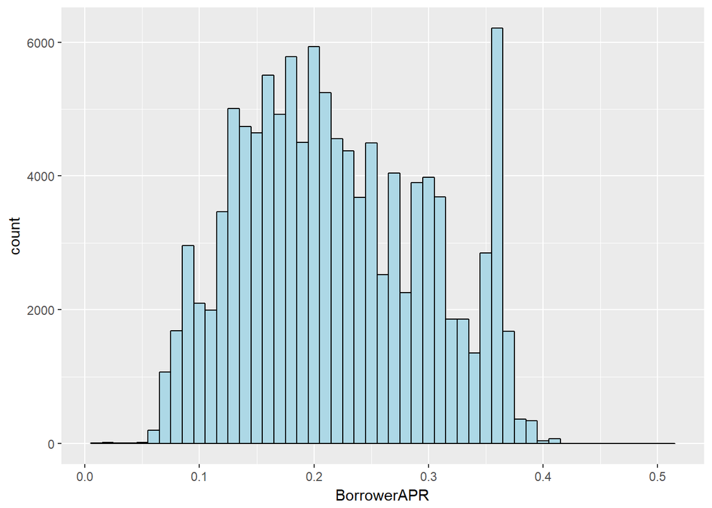

#### LoanStatus_distribution

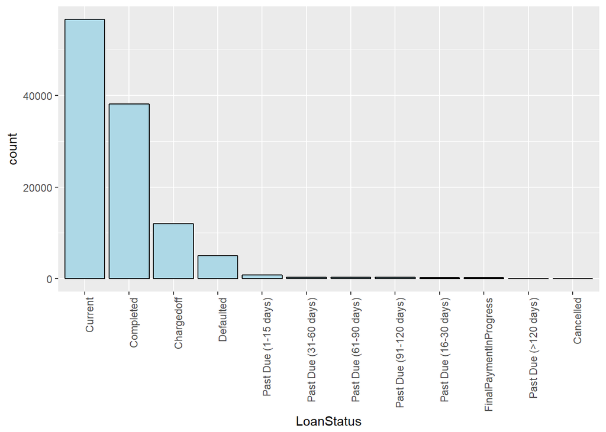

从贷款状态来看，最多的是current，其次是completed,然后是Chargedoff。

#### ProsperRating distribution

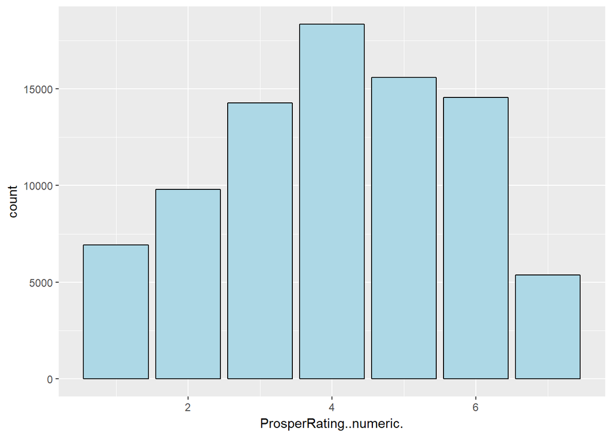

ProsperRating..numeric.的有效数据来看，最多的是4，其次是5,然后是6,最少的是7。

#### ProsperScore distribution

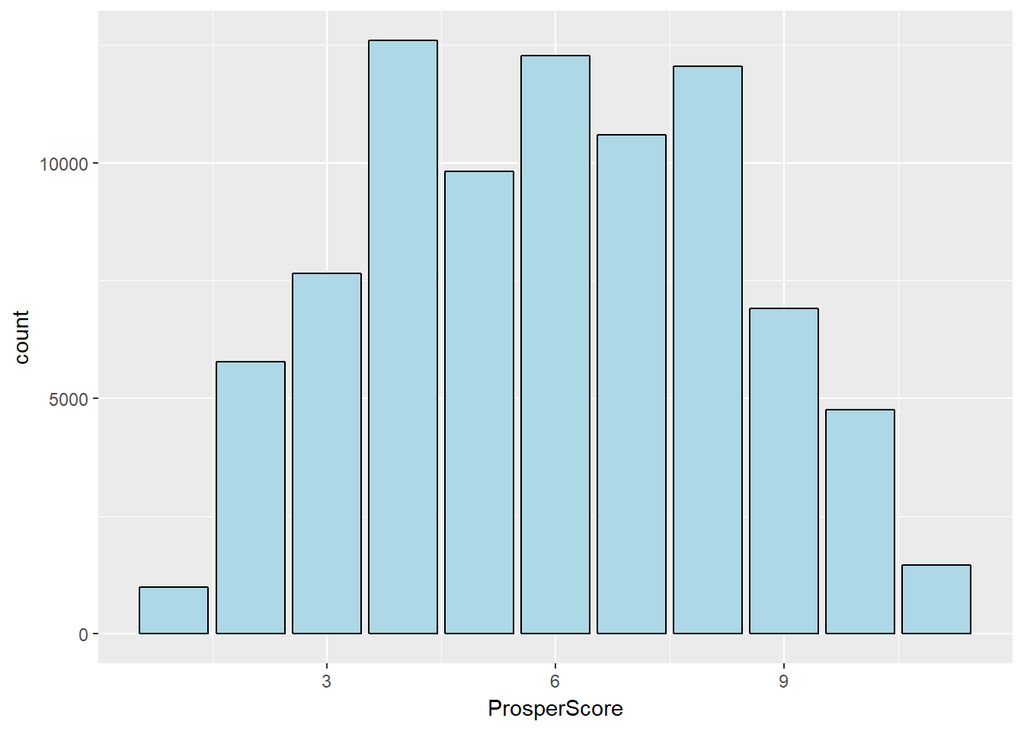

从ProsperScore来看，分布集中在3~9分。

#### ListingCategory distribution

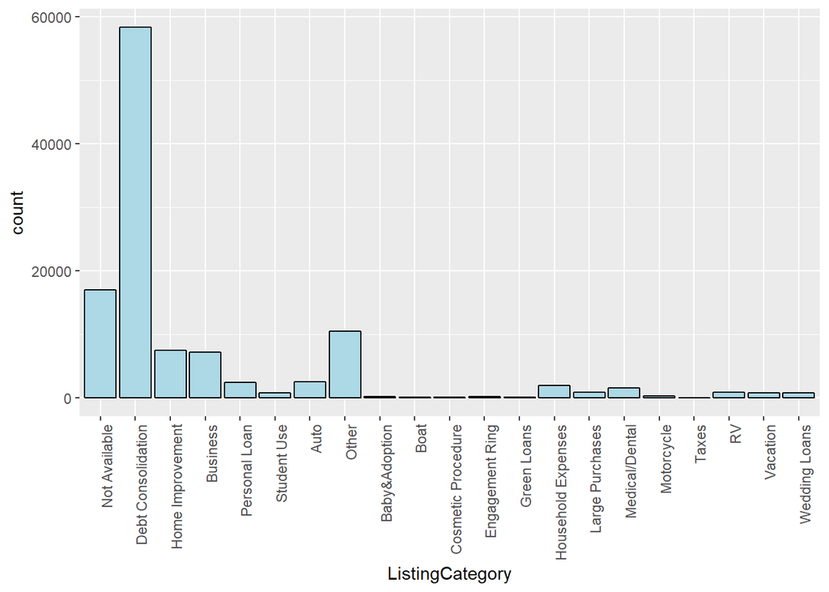

#### Count_by_BorrowerState

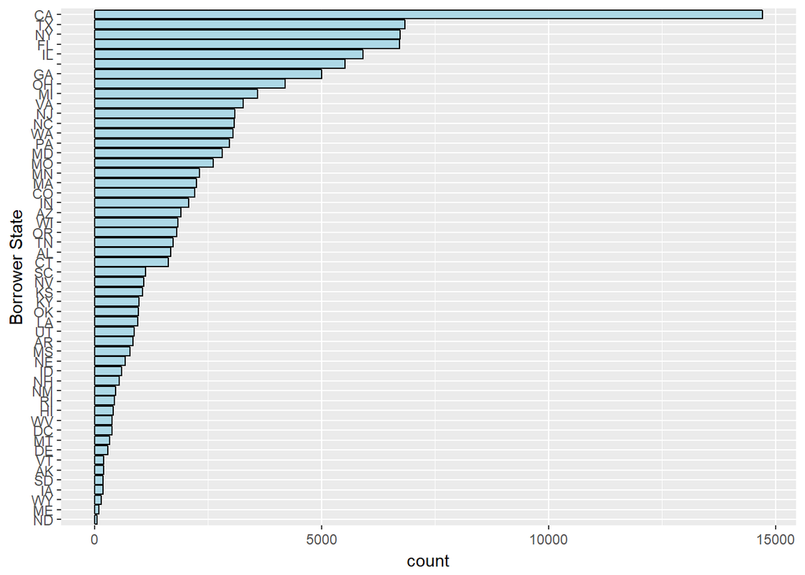

贷款次数最多的州是CA,其次是TX，然后是出于差不多水平的NY和FL；贷款频率最低的3个州分别是WY,ME和ND。

#### CurrentDelinquencies_Distribution

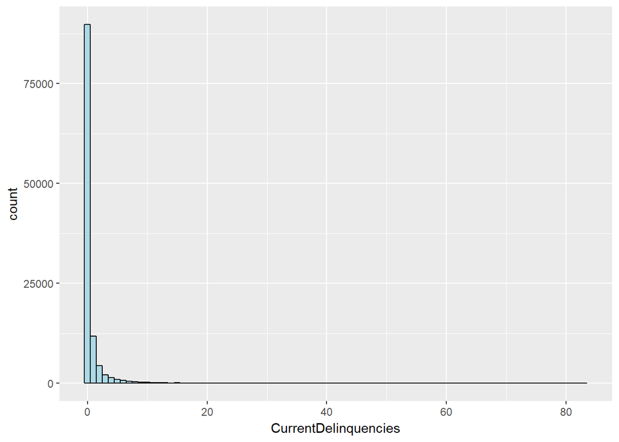

CurrentDelinquencies随着次数增加，频率逐渐降低。

#### AmountDelinquent_Distribution

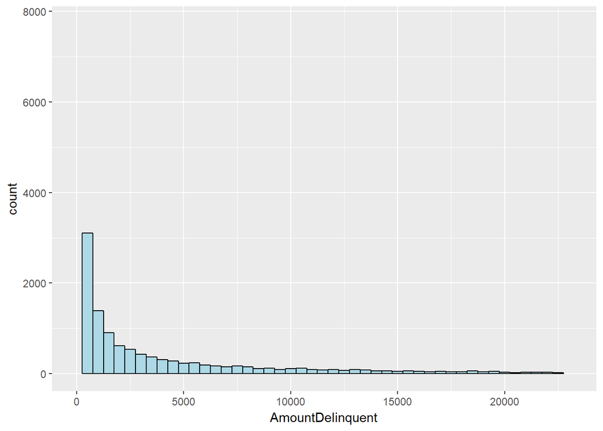

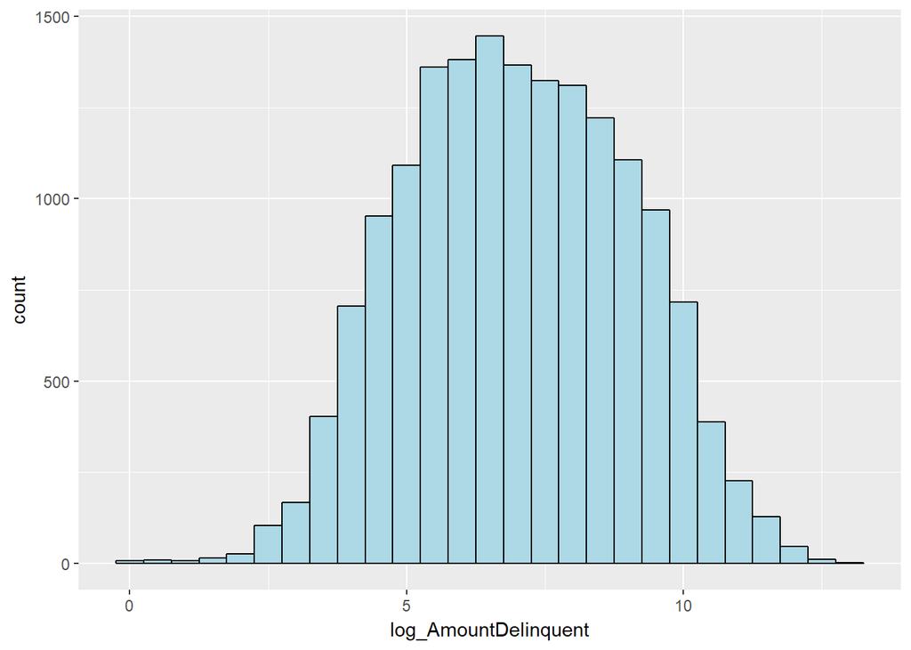

由于AmountDelinquent有离群值，对直方图分布有较大影响，所以将x轴上限设置为AmountDelinquent的0.99分位来排除离群值。从图形可以看出，AmountDelinquent的频率随着数量增加而降低，0~500这个区间出现次数最多。同时，将AmountDelinquent做log处理后，图形基本成正态分布。

#### AvailableBankcardCredit_distribution

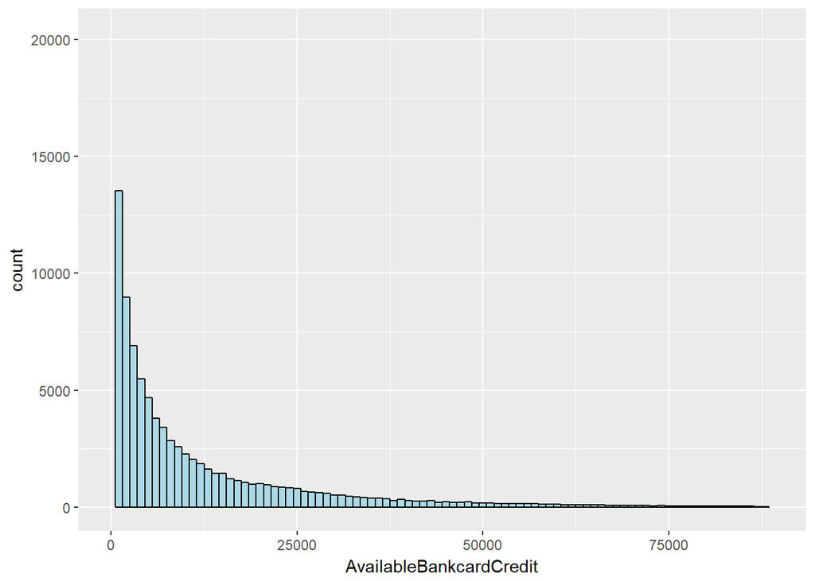

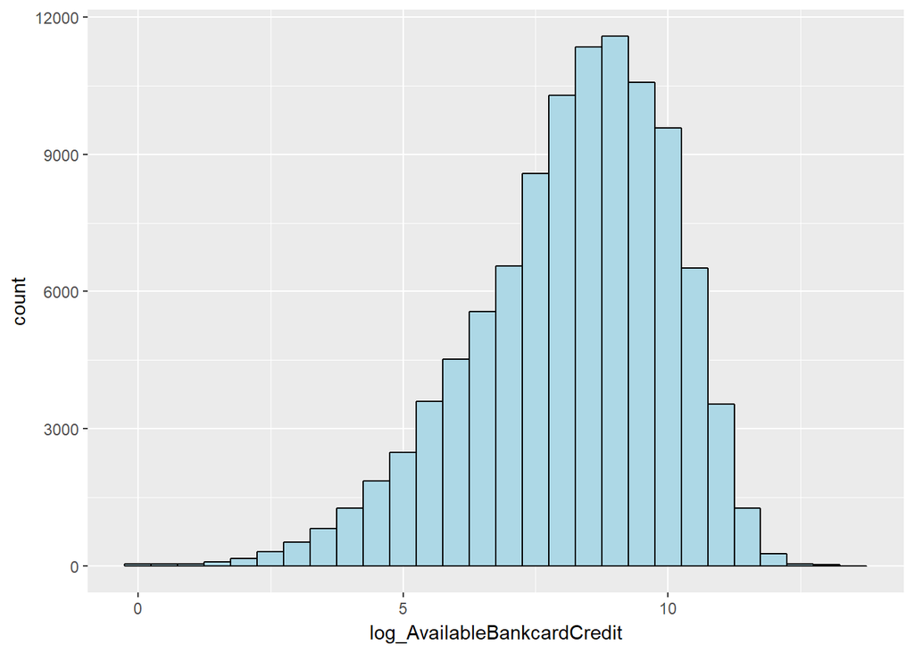

将x轴上限设置为AvailableBankcardCredit的0.99分位之后，可以看出，AvailableBankcardCredits随着数额的增加，频率逐渐降低。另一方面，将AvailableBankcardCredit做log处理后，图形分布较之前偏正态一些。

#### Count_by_EmploymentStatus

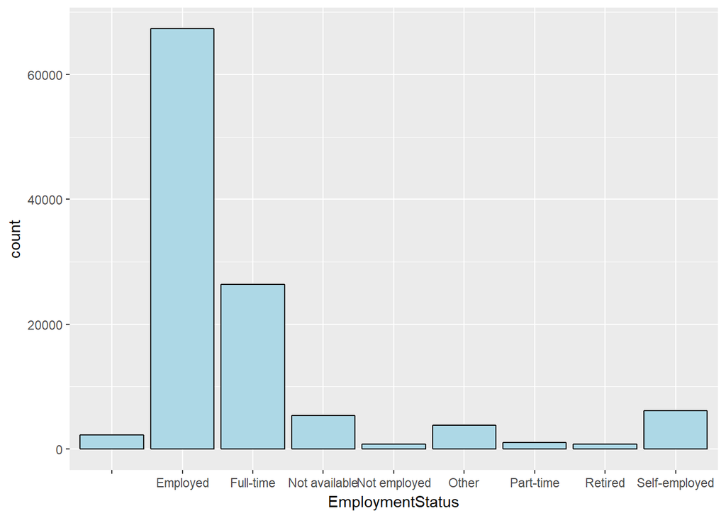

在EmploymentStatus中，状态为employed是贷款次数最多的。

#### TotalTrades_distribution

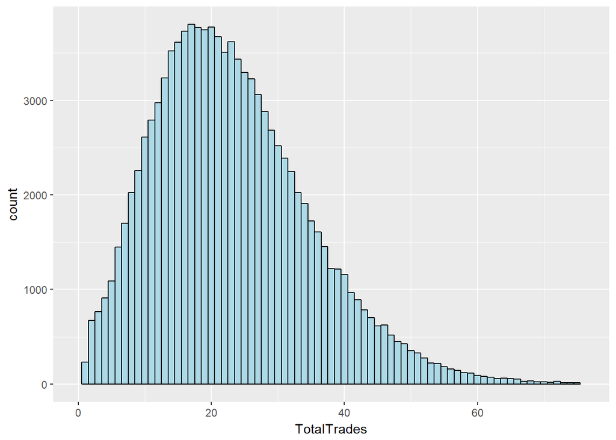

从TotalTrades来看，图形成右偏态分布，高峰集中在20附近。

#### DebtToIncomeRatio_distribution

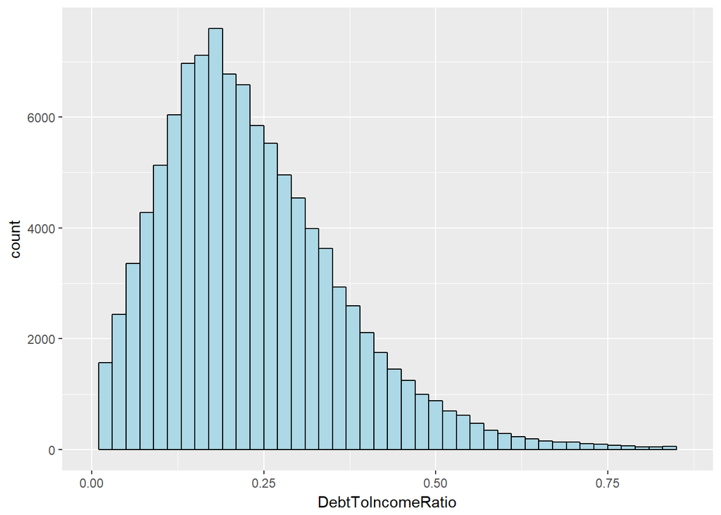

将x轴上限设置为DebtToIncomeRatio的0.99分位之后，图形呈现右偏态分布，高峰集中在0.16附近。

#### IncomeRange_distribution

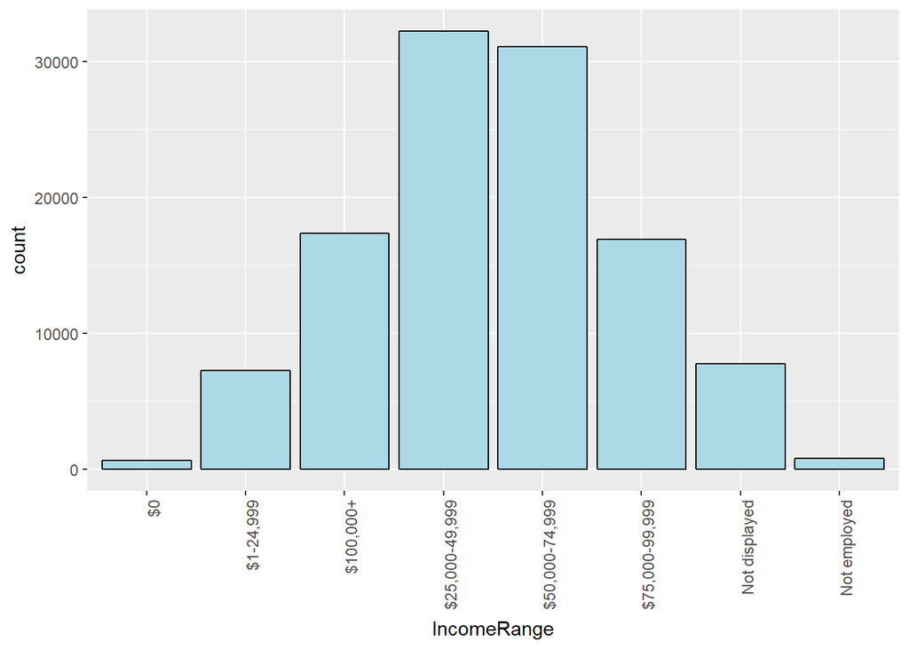

贷款人群中，收入居中的最多。

#### LoanOriginalAmount_distribution

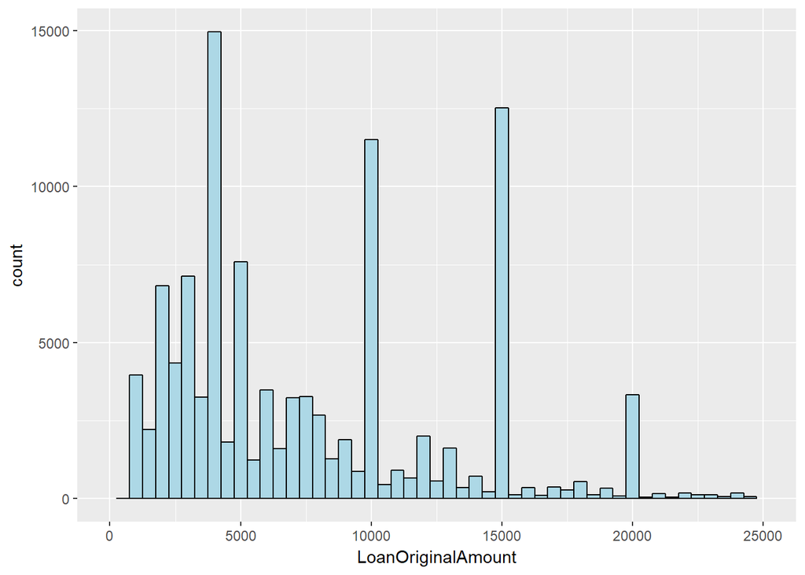

LoanOriginalAmount的分布似乎没有什么规律，且有些区间分布明显高于其他区间。

### 单变量分析

#### 你的数据集结构是什么？

数据集共有113937个观察值，81个变量，从中选取了16个变量进行探索。

#### 你的数据集内感兴趣的主要特性有哪些？

贷款额度和贷款次数，哪些变量会影响是否成功贷款或者贷款额度。

#### 你认为数据集内哪些其他特征可以帮助你探索兴趣特点？

收入，雇佣状态、银行信用额度等应该会对贷款额度有所影响。

#### 在已经探究的特性中，是否存在任何异常分布？你是否对数据进行一些操作，如清洁、调整或改变数据的形式？如果是，你为什么会这样做？

AvailableBankcardCredit分布呈右偏态分布，所以将AvailableBankcardCredit做log处理后，让图形分布较之前偏正态一些。 对TotalTrades等含有离群值的数据，在绘图是采用x轴0.99分位的方法将离群值排除。

## 双变量绘图选择

#### LoanOriginalAmount Boxplot byListingCategory

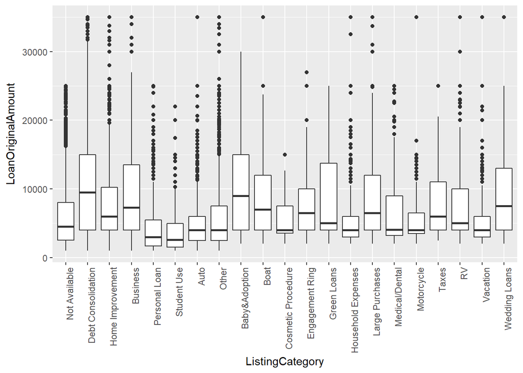

在ListingCategory中，中位数与其他相比较高的是Debt Consolidation和Baby&Adoption，这看起来是合理的，鉴于这两项确实是需要相对较高的开支。

#### LoanOriginalAmount Scatterplot by log_AvailableBankcardCredit

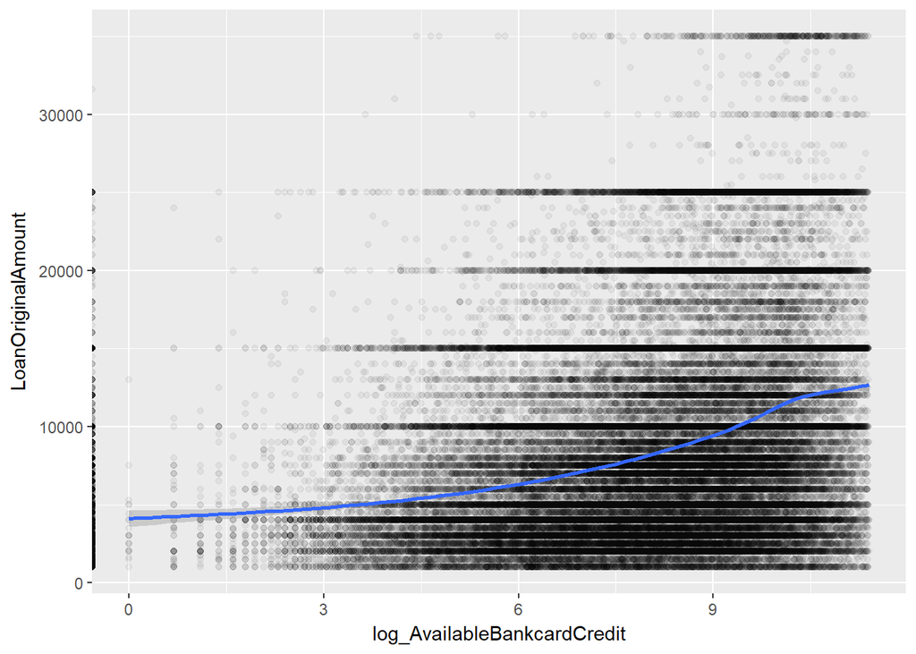

log_AvailableBankcardCredit较低的区域，相对贷款数量少，且贷款额度低，而贷款额度最高的分布则比较集中在log_AvailableBankcardCredit高的区域。

#### LoanOriginalAmount Boxplot by Term_by_year

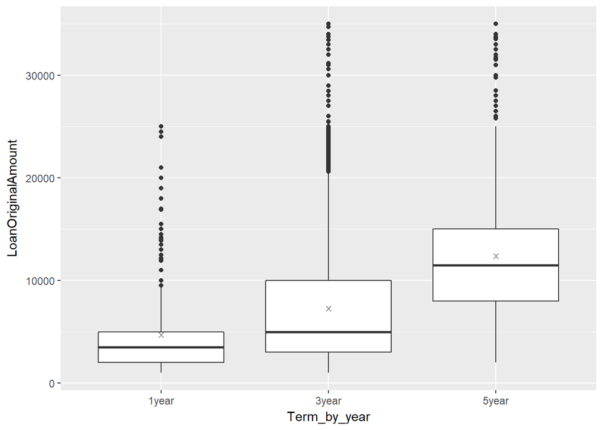

三年期的贷款中位数略高于一年期，5年期的中位数明显高于1年期和3年期，3年期的最高额与5年期基本持平，同时两者都明显高于1年期的最高额,从贷款数额的均值来看，5年期均值>3年期均值>1年期均值。

#### LoanOriginalAmount Boxplot by EmploymentStatus

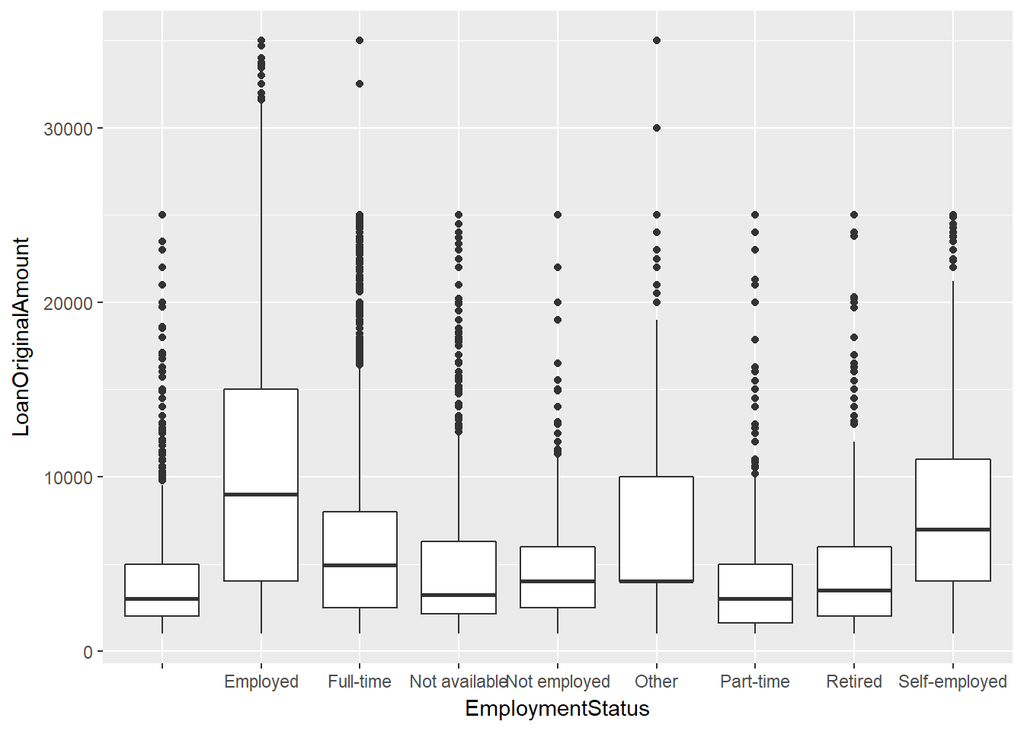

从EmploymentStatus来看，Employed的LoanOriginalAmount相对于其他状态中位数较高，最高额的相对较高。

#### LoanOriginalAmount Scatter Plot by Time

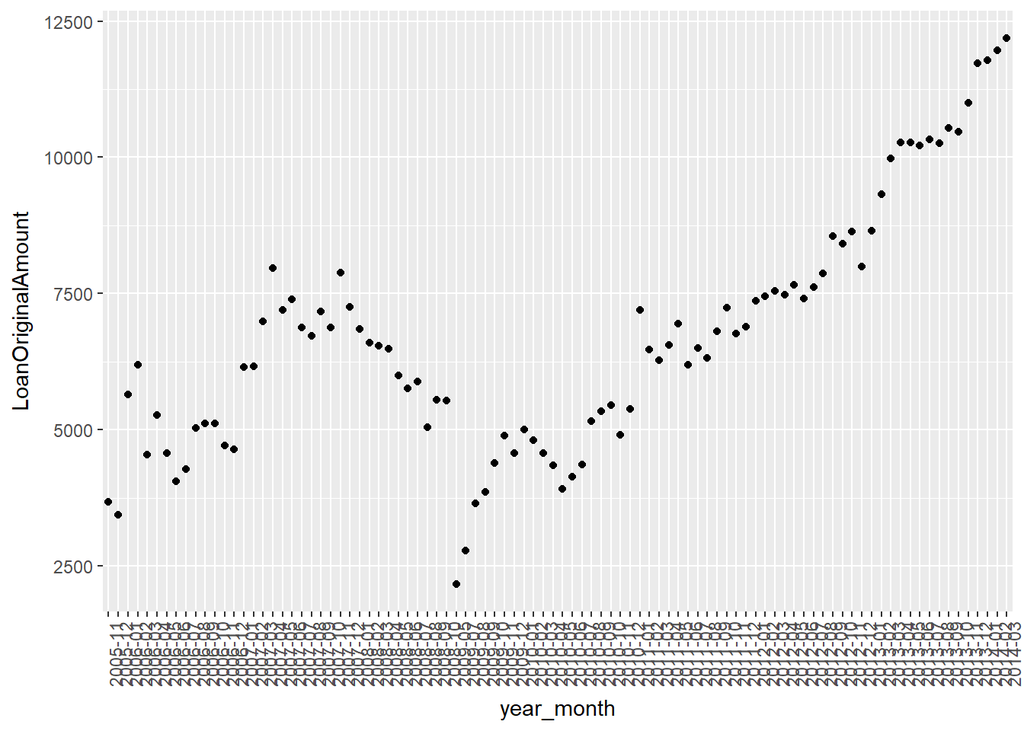

从2005年到2014年，LoanOriginalAmount均值逐渐成上升趋势，但在中间经历过一段下跌，之后又恢复持续上升的趋势。

#### LoanOriginalAmount Scatter Plot by CurrentDelinquencies

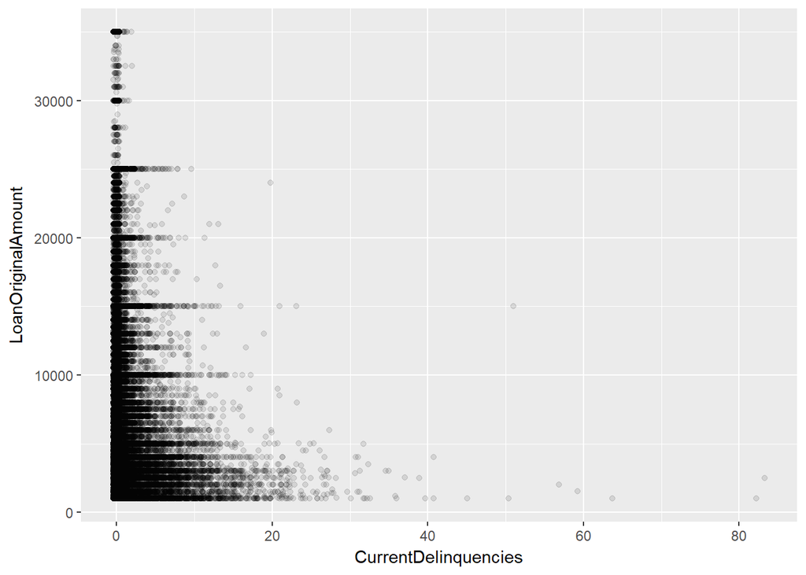

相对而言，LoanOriginalAmount较高的点都集中在CurrentDelinquencies较少的区域。

#### LoanOriginalAmount Boxplot by IncomeRange

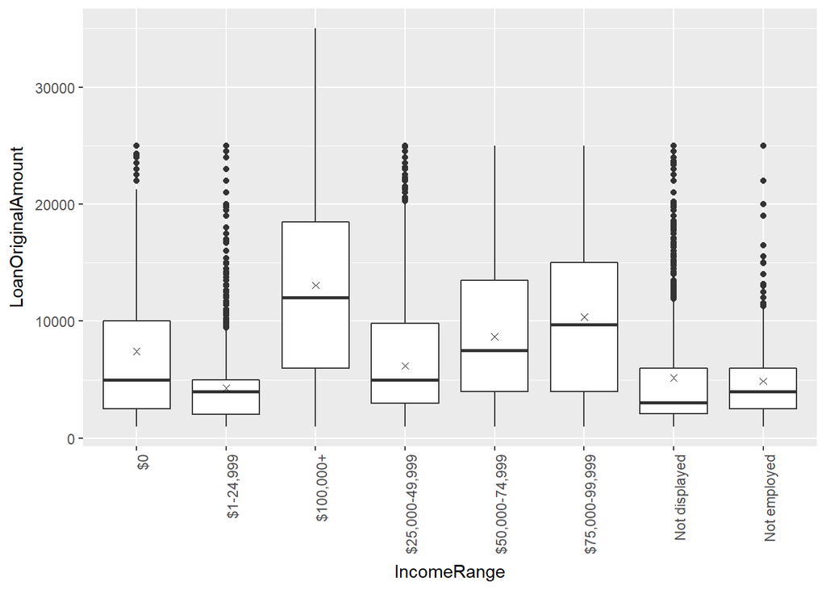

除去IncomeRange为0的部分，IncomeRange较高的范围对应LoanOriginalAmount的均值及中位数也相对较高； IncomeRange为$100,000+的LoanOriginalAmount的最高值高于其他，其余的IncomeRange相应的LoanOriginalAmount的最高值基本相同。

#### LoanOriginalAmount Scatter Plot by DebtToIncomeRatio

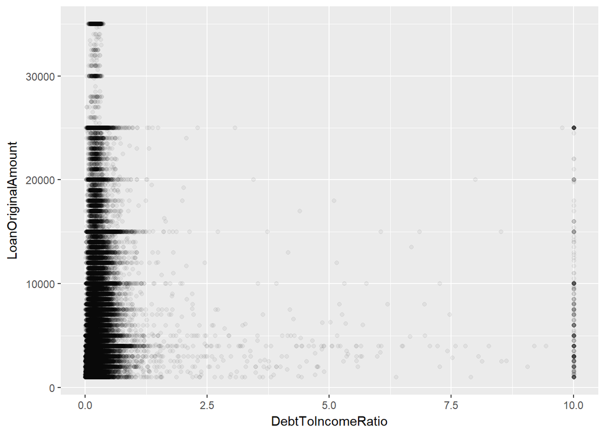

在DebtToIncomeRatio为0~1的区域中，LoanOriginalAmount随着DebtToIncomeRatio的增加而减少，但也有一些特例发生在DebtToIncomeRatio为10的情况下。

#### LoanOriginalAmount Line Chart by ProsperScore

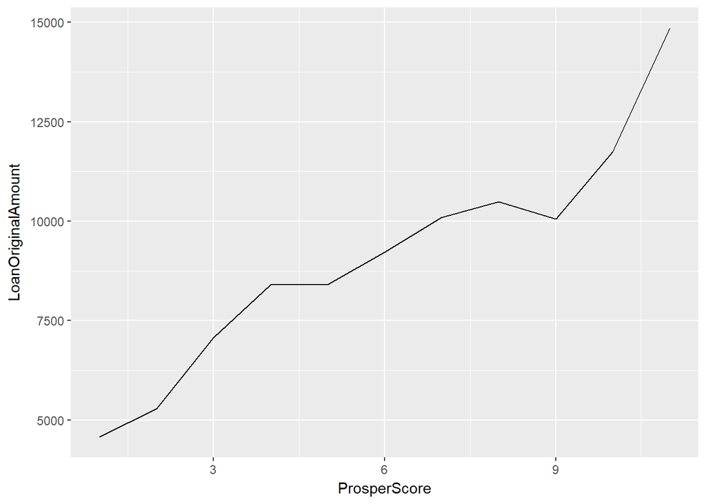

LoanOriginalAmount的均值随着ProsperScore的增加逐渐增加。

#### LoanOriginalAmount Scatter Plot by AmountDelinquent

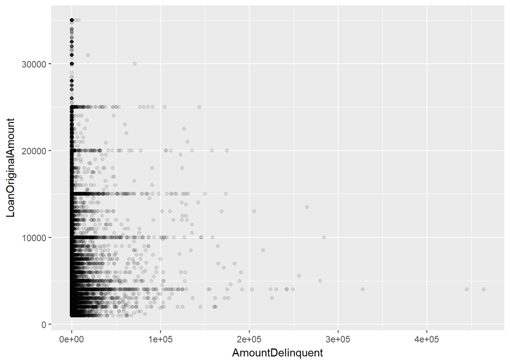

LoanOriginalAmount最高的贷款的AmountDelinquent为0，AmountDelinquent在25000以下的区域中，贷款密度较高。

#### LoanOriginalAmount Line Chart by ProsperRating

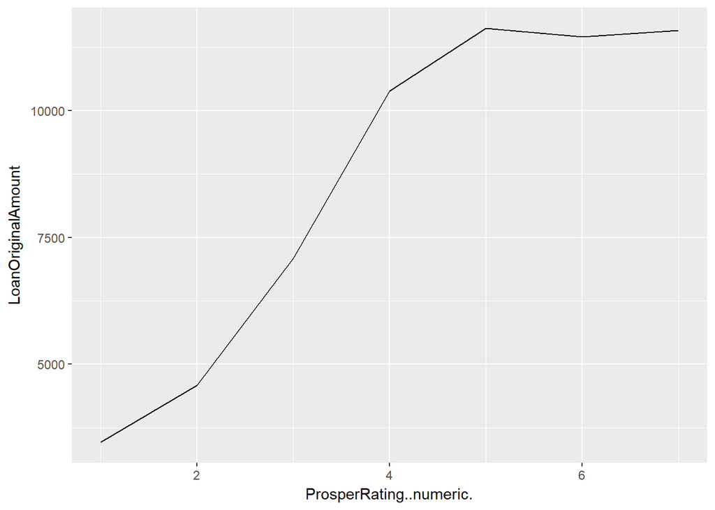

ProsperRating..numeric.为1~5时，LoanOriginalAmount均值随着ProsperRating..numeric.增加而增加，ProsperRating..numeric.为5,6,7时，LoanOriginalAmount均值基本持平。

#### LoanOriginalAmount Scatter Plot by BorrowerAPR

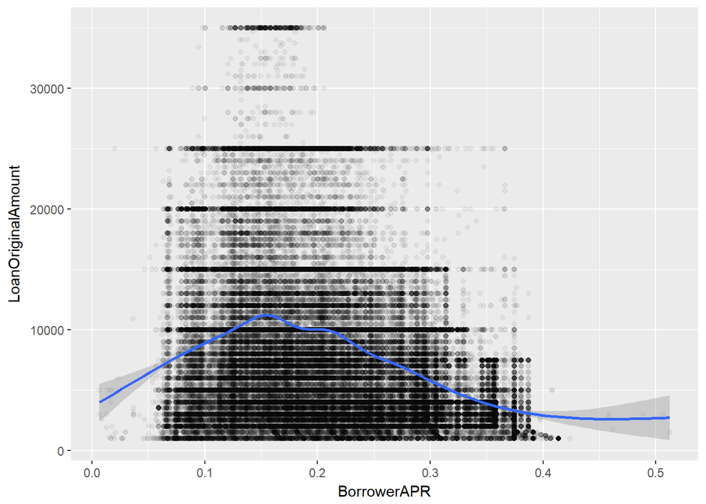

当BorrowerAPR为0.1~0.2之间时，LoanOriginalAmount相对较高。

### 双变量分析

#### 探讨你在这部分探究中观察到的一些关系。这些感兴趣的特性与数据集内其他特性有什么区别？

不同ListingCategory，Term，IncomeRangeLoan之间，OriginalAmount区别非常明显。高AvailableBankcardCredit通常意味着相对较高的LoanOriginalAmount。LoanOriginalAmount均值随着ProsperRating..numeric和ProsperScore的增加而增加。AmountDelinquent为0，LoanOriginalAmount相对较高。

#### 你是否观察到主要特性与其他特性之间的有趣关系？

ProsperRating..numeric.和ProsperScore通常成正相关关系。

## 多变量绘图选择

#### LoanOriginalAmount by Time&IncomeRange

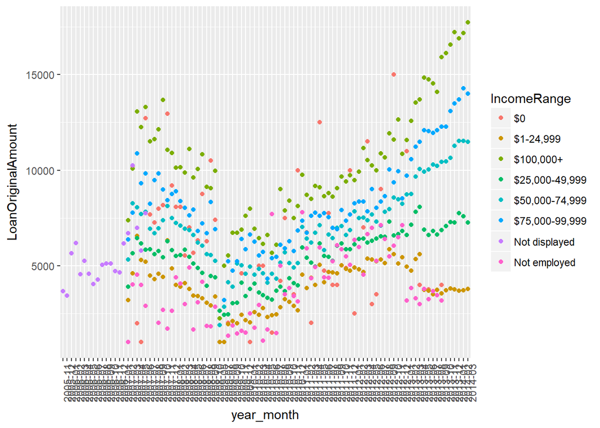

不同IncomeRange所处的LoanOriginalAmount范围虽然不同，但是趋势大致相同，除了$1-24,999范围在最后阶段处于下降趋势阶段，与其他范围趋势不同。

#### LoanOriginalAmount_Scatter_Plot_by_CurrentDelinquencies&Term_by_year

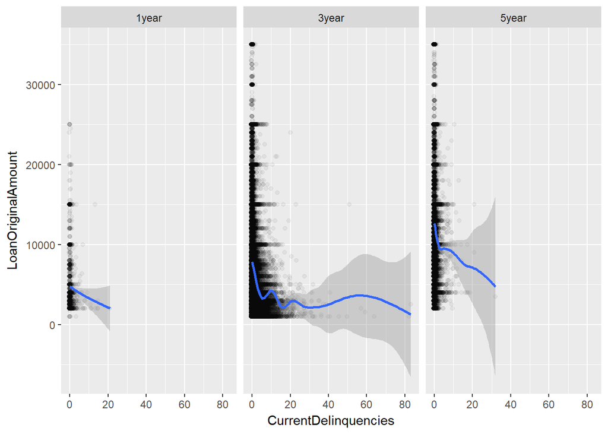

1年期，3年期，5年期贷款相比较，3年期贷款CurrentDelinquencies多于1年期和5年期，且三者的LoanOriginalAmount随着CurrentDelinquencies增加而减少，5年期减少幅度最大。

#### LoanOriginalAmount_Line_Chart by ProsperRating&Term_by_year

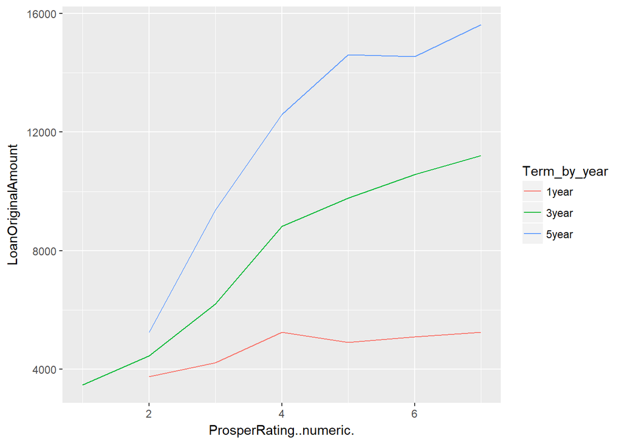

1年期贷款均值<3年期贷款均值<5年期贷款均值，三者随着ProsperRating..numeric.增加而增加，但增加幅度不同，5年期增幅最大，3年期次之，1年期最小。

#### LoanOriginalAmount_Line_Chart by ProsperRating&DebtToIncomeRatio

[figure not shown]

在DebtToIncomeRatio相对集中的区域，即0~2.5的区域中，若DebtToIncomeRatio相同时，ProsperRating低的LoanOriginalAmount也低。

#### 回归模型

```
##
## Calls:
## m1: lm(formula = I(LoanOriginalAmount) ~ I(ListingCategory), data = df_loans)
## m2: lm(formula = I(LoanOriginalAmount) ~ I(ListingCategory) + EmploymentStatus,
##     data = df_loans)
## m3: lm(formula = I(LoanOriginalAmount) ~ I(ListingCategory) + EmploymentStatus +
##     CurrentDelinquencies, data = df_loans)
## m4: lm(formula = I(LoanOriginalAmount) ~ I(ListingCategory) + EmploymentStatus +
##     CurrentDelinquencies + ProsperRating..numeric., data = df_loans)
## m5: lm(formula = I(LoanOriginalAmount) ~ I(ListingCategory) + EmploymentStatus +
##     CurrentDelinquencies + ProsperRating..numeric. + AvailableBankcardCredit,
##     data = df_loans)
## m6: lm(formula = I(LoanOriginalAmount) ~ I(ListingCategory) + EmploymentStatus +
##     CurrentDelinquencies + ProsperRating..numeric. + AvailableBankcardCredit +
##     IncomeRange, data = df_loans)
## m7: lm(formula = I(LoanOriginalAmount) ~ I(ListingCategory) + EmploymentStatus +
##     CurrentDelinquencies + ProsperRating..numeric. + AvailableBankcardCredit +
##     IncomeRange + Term, data = df_loans)
## m8: lm(formula = I(LoanOriginalAmount) ~ I(ListingCategory) + EmploymentStatus +
##     CurrentDelinquencies + ProsperRating..numeric. + AvailableBankcardCredit +
##     IncomeRange + Term + ProsperScore, data = df_loans)
##
## ========================================================================================================================================================================================================================================
##                                                                  m1                    m2                    m3                    m4                    m5                    m6                    m7                    m8
## ----------------------------------------------------------------------------------------------------------------------------------------------------------------------------------------------------------------------------------------
##   (Intercept)                                                    6253.853***           4562.865***           5394.512***           1929.867              2185.616              3609.230**           -1466.663             -1330.970
##                                                                   (45.762)             (121.806)             (143.644)            (1198.821)            (1191.463)            (1344.538)            (1275.782)            (1275.521)
##   I(ListingCategory): Debt Consolidation/Not Available           3654.499***            -84.969              -429.741***           2663.508*             2624.039*             2898.544**            2081.240*             2082.187*
##                                                                   (51.995)              (74.950)              (74.985)            (1198.596)            (1191.214)            (1117.715)            (1059.712)            (1059.383)
##   I(ListingCategory): Home Improvement/Not Available             1838.231***          -1719.743***          -2029.575***           1098.250              1013.808               960.468               299.349               325.490
##                                                                   (82.909)              (96.876)              (96.604)            (1200.123)            (1192.734)            (1119.137)            (1061.049)            (1060.726)
##   I(ListingCategory): Business/Not Available                     2673.006***           -218.119*             -530.967***           2267.076              2147.519              2359.433*             1719.748              1759.925
##                                                                   (83.882)              (95.604)              (95.348)            (1200.740)            (1193.349)            (1119.726)            (1061.605)            (1061.290)
##   I(ListingCategory): Personal Loan/Not Available               -1697.183***          -2535.726***          -2715.612***
##                                                                  (130.109)             (132.499)             (131.853)
##   I(ListingCategory): Student Use/Not Available                 -2739.285***          -3318.378***          -3573.119***           -645.131              -587.539               359.233               -91.077                 5.754
##                                                                  (221.559)             (220.583)             (219.361)            (1242.680)            (1235.027)            (1158.940)            (1098.773)            (1098.511)
##   I(ListingCategory): Auto/Not Available                        -1253.206***          -4371.997***          -4627.788***          -1201.769             -1183.754              -250.811              -614.116              -562.319
##                                                                  (126.125)             (132.261)             (131.646)            (1203.694)            (1196.280)            (1122.519)            (1064.240)            (1063.933)
##   I(ListingCategory): Other/Not Available                        -342.306***          -3592.434***          -3872.835***           -227.852              -259.659               211.329              -133.586               -89.197
```

[output cut: 60 more lines]

```
##                                                                                                                                                                                                        (1.431)               (1.431)
##   ProsperScore                                                                                                                                                                                                              -74.427***
##                                                                                                                                                                                                                             (10.159)
## ----------------------------------------------------------------------------------------------------------------------------------------------------------------------------------------------------------------------------------------
##   R-squared                                                         0.089                 0.143                 0.154                 0.274                 0.283                 0.369                 0.433                 0.433
##   adj. R-squared                                                    0.089                 0.142                 0.154                 0.274                 0.283                 0.369                 0.432                 0.433
##   sigma                                                          5960.504              5784.185              5749.285              5358.193              5325.189              4996.465              4737.029              4735.559
##   F                                                               559.400               676.405               710.928              1186.135              1195.698              1501.918              1902.558              1850.881
##   p                                                                 0.000                 0.000                 0.000                 0.000                 0.000                 0.000                 0.000                 0.000
##   Log-likelihood                                             -1152103.230          -1148677.963          -1140965.106           -848967.463           -848442.693           -843033.577           -838508.672           -838481.832
##   Deviance                                              4047163585789.735     3810996293470.122     3742074249048.452     2435345226767.153     2405408172368.099     2117478081896.415     1903269135918.110     1902065458144.187
##   AIC                                                         2304250.461           2297415.926           2281992.213           1697992.926           1696945.386           1686137.154           1677089.345           1677037.665
##   BIC                                                         2304462.615           2297705.228           2282290.968           1698264.038           1697225.847           1686464.358           1677425.897           1677383.566
##   N                                                            113937                113937                113240                 84853                 84853                 84853                 84853                 84853
## ========================================================================================================================================================================================================================================
```

### 多变量分析

#### 探讨你在这部分探究中观察到的一些关系。通过观察感兴趣的特性，是否存在相互促进的特性？

1.不同IncomeRange所处的LoanOriginalAmount范围虽然不同，但是趋势大致相同，除了$1-24,999范围在最后阶段处于下降趋势阶段，与其他范围趋势不同。  
2.1年期贷款均值<3年期贷款均值<5年期贷款均值，三者随着ProsperRating..numeric.增加而增加，但增加幅度不同，5年期增幅最大，3年期次之，1年期最小。

#### 这些特性之间是否存在有趣或惊人的联系呢？

没有

#### 选项：你是否创建过数据集的任何模型？讨论你模型的优缺点。

通过8个变量创建了线性回归模型，模型的R²基本上随着变量增加而增加，p-value<0.05,说明这些变量具有显著性，但R²为0.433，说明该模型只能在一定程度上对因变量做解释而不能很好的解释了因变量。